# Dynamic Document for Fiscal Impacts of Deworming

```r
#starting point is
# Calcs-Table 5!N21 =
# 'Assumps&Panel A Calcs'!$B$135 * 'Assumps&Panel A Calcs'!$B$10 *
# 'Model Params&Exp Profiles'!R9 * 'Model Params&Exp Profiles'!R8
```

```r
##### Data
#############
gov_bonds <-    0.1185            #Kenyan interest on sovereign debt - Central Bank of Kenya
inflation <-  0.02              #Kenyan inflation rate - World Bank Development Indicators
wage_ag_val <-  11.84             #Mean hourly wage rate (KSH) - Suri 2011
wage_ww_val <-  14.5850933      #Control group hourly wage, ww (cond >=10 hrs per week) - Table 4, Panel B
profits_se_val <- 1766          #Control group monthly self-employed profits - Table 4, Panel A  FIX: MOST REFERENCES FROM TABLE 4 ARE TABLE 3
hours_se_cond_val <- 38.1       #Control group weekly self-employed hours, conditional on hrs >0 - Table D13, Panel D
hours_ag_val <- 8.3             #Control group hrs per week, agriculture - Table 4, Panel D
hours_ww_val <- 6.9             #Control group hrs per week, working for wages - Table 4, Panel B
hours_se_val <- 3.3             #Control group hrs per week, self-employment - Table 4, Panel A
ex_rate_val <- 85               #Exchange Rate - Central Bank of Kenya
growth_rate_val <- 1.52/100     #Per-capita GDP growth, 2002-2011 (accessed 1/29/13) -  World Bank - see notes
coverage_val  <- 0.681333333    # (R) Fraction of treated primary school students within 6 km - from W@W - see note
tax_val <- 0.16575              #ADD INFO
unit_cost_local_val <- 43.66    #Deworm the World
years_of_treat_val <- 2.41      #Additional Years of Treatment - Table 1, Panel A

##### Research
#############
lambda1_vals <- c(3.49, 0)      #Hrs per week increase for men and women CONFIRM
lambda2_val <- 10.2             #Externality effect (proportional) - Table 3, Panel B
q_full_val <- 0.75              #Take up rates with full subsidy. From Miguel and Kremmer (2007)
q_zero_val <- 0                 #Take up rates with zero subsidy. From Miguel and Kremmer (2007)
delta_ed_vals <- c(-0.00176350949079451, 0.00696052250263997, 0.0258570306763183,     # (Delta E) Additional direct seconday schooling increase (from Joan)
                    0.0239963665555466, 0.027301406306074, 0.0234125454594173,
                   0.0279278879439199, 0.00647044449446303, 0.00835739437790601)
delta_ed_vals <- cbind(delta_ed_vals, 1999:2007)
delta_ed_ext_vals <- c(-0.0110126908021048, 0.0140448546741008, -0.0034636291545585,  #Additional externality secondary schooling increase (from Joan)
                       0.0112940214439477,  0.0571608179771775, -0.0560546793186931,
                       0.0558284756343451,  0.1546264843901160, 0.0055961489945619)
delta_ed_ext_vals <- cbind(delta_ed_ext_vals, 1999:2007)

##### Guess work
#############
periods_val <- 50               #Total number of periods to forecast wages
time_to_jm_val <- 10            #Time from intial period until individual join the labor force
coef_exp_val <- c(0, 0)         #Years of experience coefficients (1-linear, 2-cuadratic)   - see notes
teach_sal_val <- 5041           #Yearly secondary schooling compensation    5041 - from ROI materials
teach_ben_val <- 217.47         #Yearly secondary schooling teacher benefits    217.47
n_students_val <- 45            #Average pupils per teacher 45


##### Notes:
#############
# on growth_rate_val: (http://data.worldbank.org/indicator/NY.GDP.PCAP.KD/), see calculation on "Kenya GDP per capita" tab. In W@W this equals 1.52%. ISSUE: This growth number should be updated to be 2002-2014, I think.
# on coef_exp_val: 1998/1999 Kenyan labor force survey; regression of earnings on age, age^2, female dummy, indicators for attained primary/secondary/beyond, and province dummies. Estimate used in W@W: (0.1019575, -0.0010413). ISSUE: For now assume no further life cycle adjustment beyond KLPS-3 (likely a conservative assumption).
# coverage_val: Overall Saturation (0.511) / 0.75 - not reported in table, average of T & C
```

[Original paper paper](https://academic.oup.com/qje/article/131/4/1637/2468871)

## Who are the policy makers?

- Ministries of Health, Education and Finance.

## What is the relevant output that should be used to inform them?

- NPV from government perspective.
- NPV from social planner perspective.

## Proposed output:

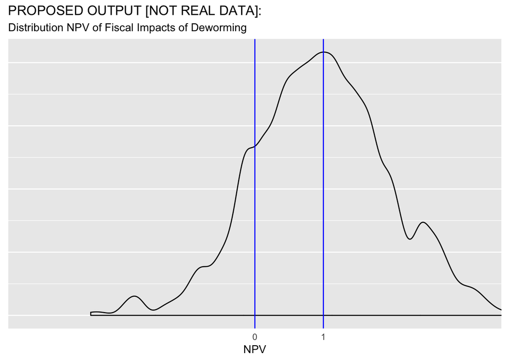

## Main Equation (the model)

$$\begin{equation}
NPV = \sum_{\gamma} N_{\gamma} \left[
\tau \sum_{t=0}^{50} \left( \frac{1}{1 + r}\right)^{t} w_{t}
\left( \lambda_{1, \gamma} + \frac{p \lambda_{2, \gamma}}{R} \right) -
K \sum_{t=0}^{50} \left( \frac{1}{1 + r}\right)^{t} \Delta \overline{E}_{\gamma t}(S1,S2)
\right] - \left( S_{2}Q(S_{2}) - S_{1}Q(S_{1}) \right)
\label{eq:1}
\tag{1}
\end{equation}$$

```r
# Gamma is used to index gender.
npv <- function(n_male=1/2, n_female=1/2,
                interest_r=interst_r_val,
                wage=wage_t_val,
                lambda1_male=lambda1_vals[1],
                lambda1_female=lambda1_vals[2],
                tax=tax_val,
                saturation=saturation_val,
                coverage=coverage_val,
                cost_of_schooling=cost_per_student,
                delta_ed_male=delta_ed_vals[,1],
                delta_ed_female=delta_ed_vals[,1],
                lambda2_male=lambda2_vals[1],
                lambda2_female=lambda2_vals[2],
                s1=0, q1=0, s2=s2_val, q2=q2_val,
                periods=periods_val) {
  ns <- c(n_male, n_female)
  lambda1s <- c(lambda1_male, lambda1_female)
  lambda2s <- c(lambda2_male, lambda2_female)
  index_t <- 0:periods
  delta_ed_s <- cbind(delta_ed_male, delta_ed_female)
  delta_ed_s <- rbind(c(0,0), delta_ed_s, matrix(0,41, 2) )

  benef <- matrix(NA, 51,2)
  for (i in 1:2){
  benef[,i] <- ( 1 / (1 + interest_r) )^index_t * wage *
                     ( lambda1s[i] + saturation * lambda2s[i] / coverage )
  }

  res1 <- sum( ns * ( tax * apply(benef, 2, sum) -
            apply( ( 1 / (1 + interest_r) )^index_t *
                     delta_ed_s * cost_of_schooling, 2, sum) )
          ) - (s2 * q2  - s1 * q1)
#  browser()
  return(res1)
}
```

## Sub components:

### 1 - “$r$”

$$\begin{equation}
NPV = \sum_{\gamma} N_{\gamma} \left[
\tau \sum_{t=0}^{50} \color{blue}{\left( \frac{1}{1 + r}\right)}^{t} w_{t}
\left( \lambda_{1, \gamma} + \frac{p \lambda_{2, \gamma}}{R} \right) -
K \sum_{t=0}^{50} \color{blue}{\left( \frac{1}{1 + r}\right)}^{t} \Delta \overline{E}_{\gamma t}(S1,S2)
\right] - \left( S_{2}Q(S_{2}) - S_{1}Q(S_{1}) \right)
\end{equation}$$

The real interest rate $r$ is obtained from the interest rate on betterment bonds (0.118) minus the inflation rate (0.02).

```r
interst_r_val <- gov_bonds - inflation
```

### 2 - “$w_{t}$”

$$\begin{equation}
NPV = \sum_{\gamma} N_{\gamma} \left[
\tau \sum_{t=0}^{50}\left( \frac{1}{1 + r}\right)^{t} \color{blue}{ w_{t} }
\left( \lambda_{1, \gamma} + \frac{p \lambda_{2, \gamma}}{R} \right) -
K \sum_{t=0}^{50} \left( \frac{1}{1 + r}\right)^{t} \Delta \overline{E}_{\gamma t}(S1,S2)
\right] - \left( S_{2}Q(S_{2}) - S_{1}Q(S_{1}) \right)
\end{equation}$$

$$\begin{equation}
w_t = \text{#weeks} \times w_0 (1 + g)^{Xp}(1 + \hat{\beta_1} Xp + \hat{\beta_2} Xp^2) \quad \text{for } t=10, \dots, 50
\end{equation}$$

#### 2.1 - “$w_0$”

$$\begin{equation}
w_t = \text{#weeks} \times \color{blue}{w_0} (1 + g)^{Xp}(1 + \hat{\beta_1} Xp + \hat{\beta_2} Xp^2)
\end{equation}$$

$$\begin{equation}
w_0 = \frac{1}{ex} \sum_{l \in \{ag, ww, se\}}w_{l}\alpha_{l} \\ \quad \text{with: } \alpha_{l}= \frac{ h_{l}}{h_{ag} + h_{ww} + h_{se}}
\end{equation}$$

The initial wage in dollars ($w_{0}$) is a weighted average of wages for control group in agriculture, working wage, and self-employed sectors ($ag, ww, se$). The weights correspond to the average number of hours in each sector ($h_l$) relative to the sum of the average number of hours in each sector.

The wage in agriculture comes from research (Suri, 2011), the working wage comes from the data and its defined as hourly wage for the control group for those who reported more than 10 hrs of work per week. The self-employed wage ($w_{se}$) was constructed as follows:

$$\begin{equation}
w_{se} = \frac{ \text{Monthly self-employed profits} }{4.5 \times E[h_{se}|h_{se}>0] }
\end{equation}$$

Where both parameters (Monthly self-employed profits and self-employed hours for the control group, conditional on hrs >0 - $E[h_{se}|h_{se}>0]$ -) come from the data (ww paper). The measure of hours in self employment used to compute wages is ($E[h_{se}|h_{se}>0]$) is different from the one is to compute the weights $\alpha_l$ above. The first one captures hours of work among those actively employed in the self-employed sector, and the second one captures the average hours of work in self-employed among all the population of workin age in the sample (hence capturing the relative inportance of the self employed sector in the economy)

```r
wage_0_f <- function(wage_ag = wage_ag_val,
                     wage_ww = wage_ww_val,
                     profits_se = profits_se_val,
                     hours_se_cond = hours_se_cond_val,
                     hours_ag = hours_ag_val,
                     hours_ww = hours_ww_val,
                     hours_se = hours_se_val,
                     ex_rate = ex_rate_val) {
  wage_se <- profits_se / (4.5 * hours_se_cond)
  wage_ls <- c(wage_ag, wage_ww, wage_se)
  alpha_ls <- c(hours_ag, hours_ww, hours_se) / sum( c(hours_ag, hours_ww, hours_se) )
  res1 <- 1/ex_rate * sum( wage_ls * alpha_ls )
  return(res1)
}

#close to value from spreadsheet (Assumps&Panel A Calcs!B137 = 0.1481084),
#but I suspect diff due to computational precision

wage_0_val <- wage_0_f()

experience_val <- 0:periods_val - time_to_jm_val

wage_t <- function(wage_0 = wage_0_val,
                   growth_rate = growth_rate_val,
                   experience = experience_val,
                   coef_exp1 = coef_exp_val[1],
                   coef_exp2 = coef_exp_val[2]) {
  res1 <- 52 * wage_0 *( ( 1 + growth_rate )^experience ) *
    ( 1 + coef_exp1 * experience + coef_exp2 * experience^2 ) *
    ifelse(0:periods_val >= time_to_jm_val, 1, 0)
  return(res1)
}

#close to value from spreadsheet (Calcs-Table 5!N21.. = 7.701634678),
#but I suspect diff due to computational precision
wage_t_val <- wage_t()
```

### 3 - “$\lambda_{1,\gamma}$” and “$\lambda_{2,\gamma}$”

$$\begin{equation}
NPV = \sum_{\gamma} N_{\gamma} \left[
\tau \sum_{t=0}^{50}\left( \frac{1}{1 + r}\right)^{t} w_{t}
\left(\color{blue}{ \lambda_{1, \gamma} } + \frac{p \color{blue}{\lambda_{2, \gamma}}}{R} \right) -
K \sum_{t=0}^{50} \left( \frac{1}{1 + r}\right)^{t} \Delta \overline{E}_{\gamma t}(S1,S2)
\right] - \left( S_{2}Q(S_{2}) - S_{1}Q(S_{1}) \right)
\end{equation}$$

$\lambda_{1,\gamma}$ represents the estimated impact of deworming on hours of work for men a women. This two parameter are combined with a underweighted mean:

$$\begin{equation}
\lambda_{1} = \frac{1}{2} \lambda_{1,male} + \frac{1}{2} \lambda_{1,female}
\end{equation}$$
Its components come from research (W@W).

```r
lambda1_vals <- rep(0.5 * lambda1_vals[1] + 0.5 *lambda1_vals[2], 2)
lambda2_vals <- rep(lambda2_val, 2)
```

### 4 - $R$ and $p$

(until clarify will be using $R$ and $p$ as the primitive values)

$$\begin{equation}
NPV = \sum_{\gamma} N_{\gamma} \left[
\tau \sum_{t=0}^{50}\left( \frac{1}{1 + r}\right)^{t} w_{t}
\left( \lambda_{1, \gamma} + \frac{\color{blue}{p} \lambda_{2, \gamma}}{\color{blue}{R}} \right) -
K \sum_{t=0}^{50} \left( \frac{1}{1 + r}\right)^{t} \Delta \overline{E}_{\gamma t}(S1,S2)
\right] - \left( S_{2}Q(S_{2}) - S_{1}Q(S_{1}) \right)
\end{equation}$$

The coverage, $R$, is defined as the fraction, among all neighboring schools (within 6 km), that belongs to the treatment group (last paragraph of page 9(1645) of paper).

$$\begin{equation}
R \equiv \frac{\text{Overall Saturation} }{Q(full)}
\end{equation}$$

The saturation of the intervention, $p$, measures the fraction of the population that is effectively usign the treatment and is defined as:

$$\begin{equation}
p = R \times Q(full) + (1 - R) \times Q(0)
\end{equation}$$

Here R is taken as given [CHECK WITH TED] and $Q(0)$ is assinged the value of 0 per the same research source.

**Note:** there is a circularity on how parameters are defined here. Everything depends on Full Saturation ($Q(full)$) at the end of the day.

```r
#R
#p
saturation_val <- coverage_val * q_full_val + ( 1 - coverage_val ) * q_zero_val
```

### 5 - $K$ and $\Delta \overline{E}_{\gamma t}(S1,S2)$

$$\begin{equation}
NPV = \sum_{\gamma} N_{\gamma} \left[
\tau \sum_{t=0}^{50}\left( \frac{1}{1 + r}\right)^{t} w_{t}
\left( \lambda_{1, \gamma} + \frac{p \lambda_{2, \gamma}}{R} \right) -
\color{blue}{K} \sum_{t=0}^{50} \left( \frac{1}{1 + r}\right)^{t} \color{blue}{ \Delta \overline{E}_{\gamma t}(S1,S2) }
\right] - \left( S_{2}Q(S_{2}) - S_{1}Q(S_{1}) \right)
\end{equation}$$

$K$ represents the cost per student. This is calculated as the salary of the teacher plus benefits, divided by the average number of students per teacher.

$$\begin{equation}
K = \frac{\text{teacher salary} + \text{teacher benefits}}{\text{# Students}}
\end{equation}$$

```r
cost_per_student <- (teach_sal_val + teach_ben_val) / n_students_val
```

For $\Delta \overline{E}_{\gamma t}(S1,S2)$ we use a series of estimated effects the additional direct increase in secondary schooling from 1999 to 2007 obtained from [need to define the source “from Joan” in `Assumps&Panel A Calcs!A93`].

This series does not take into account the externality effects. To incorporate the we need another series (same source) that estimates the additional secondary schooling increase due to the externality and add it to the original series.

```r
# Nothing here yet with delta_ed_vals, but would like to incorporate model from Joan
# delta_ed_vals <-
delta_ed_ext_total <- delta_ed_ext_vals[,1] + delta_ed_vals[,1]
```

**Note:** need to understand better the date of each component (of the model, not only this section).

### 6 - $\left( S_{2}Q(S_{2}) - S_{1}Q(S_{1}) \right)$

$$\begin{equation}
NPV = \sum_{\gamma} N_{\gamma} \left[
\tau \sum_{t=0}^{50}\left( \frac{1}{1 + r}\right)^{t} w_{t}
\left( \lambda_{1, \gamma} + \frac{p \lambda_{2, \gamma}}{R} \right) -
K \sum_{t=0}^{50} \left( \frac{1}{1 + r}\right)^{t} \Delta \overline{E}_{\gamma t}(S1,S2)
\right] - \color{blue}{ \left( S_{2}Q(S_{2}) - S_{1}Q(S_{1}) \right) }
\end{equation}$$

#### 6.1 - $S_{1}Q(S_{1}) = 0$

There is no subsidy for deworming under the status quo.

#### 6.2 - $S_{2}$: complete subsidy to per capita costs of deworming.

With complete subsidy, $S_2$ represents the total direct costs of deworming in USD. Calculated as follows

$$\begin{equation}
S_{2} = \frac{\text{Cost per person per year (KSH)} }{ex}\times \text{Additional years of treatment} \\
\end{equation}$$

#### 6.3 - $Q_{2}$

The take-up with full subsidy ($Q_2$) comes from a previous study (Miguel and Kremer 2007) and takes the value of 0.75.

```r
s2_val <- ( unit_cost_local_val / ex_rate_val ) * years_of_treat_val
q2_val <- q_full_val
```

### Main results

```r
#no externality NPV
res_npv_no_ext <- npv(lambda2_male = 0, lambda2_female = 0)

#yes externality NPV
res_npv_yes_ext <- npv(delta_ed_male = delta_ed_ext_total,
                       delta_ed_female = delta_ed_ext_total )
```

- **NPV without externalities ($\lambda_2 = 0$):** -0.6097
- **NPV with externalities ($\lambda_2 = 10.2$ ):** 34.3187

## Montecarlo simulations

Describe approach to MC:  
- Everything normal with sd= 0.1 * mean  
- Need to work with experts to add more realistic parameters and distributions.

```r
#34.8401

# generate draws of primitive values:
#  inputs: K primitive means and K standard deviations
#  output: K vectors with draws from simulations
# compute the elements of the model
#  input: K vectors with draws from sims
#  output: Input vectors for NPV function
# run the model Nsims times
#  input: Input vectors for NPV function
#  output: one vector of NPVs (of lenght Nsims)

# All variable args should use the _var subscript
sim.data1 <- function(nsims = 1e4,
                      gov_bonds_var,                #Data
                      gov_bonds_sd_var,
                      inflation_var,
                      inflation_sd_var,
                      wage_ag_var,
                      wage_ag_sd_var,
                      wage_ww_var,
                      wage_ww_sd_var,
                      profits_se_var,
                      profits_se_sd_var,
                      hours_se_cond_var,
                      hours_se_cond_sd_var,
                      hours_ag_var,
                      hours_ag_sd_var,
                      hours_ww_var,
                      hours_ww_sd_var,
                      hours_se_var,
                      hours_se_sd_var,
                      ex_rate_var,
                      ex_rate_sd_var,
                      growth_rate_var,
                      growth_rate_sd_var,
                      coverage_var,
                      coverage_sd_var,
                      saturation_var,
                      saturation_sd_var,
                      tax_var,
                      tax_sd_var,
                      unit_cost_local_var,
                      unit_cost_local_sd_var,
                      years_of_treat_var,
                      years_of_treat_sd_var,
                      lambda1_var,                   #Research
                      lambda1_sd_var,
                      lambda2_var,
                      lambda2_sd_var,
                      q_full_var,
                      q_full_sd_var,
                      q_zero_var,
                      q_zero_sd_var,
                      delta_ed_par1_var,
                      delta_ed_sd1_var,
                      delta_ed_par2_var,
                      delta_ed_sd2_var,
                      coef_exp_var,                  #Guesswork
                      coef_exp_sd_var,
                      teach_sal_var,
                      teach_sal_sd_var,
                      teach_ben_var,
                      teach_ben_sd_var,
                      n_students_var,
                      n_students_sd_var,
                      include_ext_var=TRUE
                      ) {
  set.seed(1234)

  ########
  #FUNCTION1
  #Defaoult dist: normal, default sd: 0.1* mean
  ## Data
  gov_bonds_sim <-            rnorm(n = nsims, mean = gov_bonds_var, sd = gov_bonds_sd_var)
  inflation_sim <-            rnorm(nsims, inflation_var, inflation_sd_var)
  wage_ag_val_sim <-          rnorm(nsims, wage_ag_var, wage_ag_sd_var)
  wage_ww_val_sim <-          rnorm(nsims, wage_ww_var, wage_ww_sd_var)
  profits_se_val_sim <-       rnorm(nsims, profits_se_var, profits_se_sd_var)
  hours_se_cond_val_sim <-    rnorm(nsims, hours_se_cond_var, hours_se_cond_sd_var)
  hours_ag_val_sim <-         rnorm(nsims, hours_ag_var, hours_ag_sd_var)
  hours_ww_val_sim <-         rnorm(nsims, hours_ww_var, hours_ww_sd_var)
  hours_se_val_sim <-         rnorm(nsims, hours_se_var, hours_se_sd_var)
  ex_rate_val_sim <-          rnorm(nsims, ex_rate_var, ex_rate_sd_var)
  growth_rate_val_sim <-      rnorm(nsims, growth_rate_var, growth_rate_sd_var)
  coverage_val_sim <-         rnorm(nsims, coverage_var, coverage_sd_var)
  saturation_val_sim <-       rnorm(nsims, saturation_var, saturation_sd_var)    #TO DELETE
  tax_val_sim <-              rnorm(nsims, tax_var, tax_sd_var)
  unit_cost_local_val_sim <-  rnorm(nsims, unit_cost_local_var, unit_cost_local_sd_var)
  years_of_treat_val_sim <-   rnorm(nsims, years_of_treat_var, years_of_treat_sd_var)

  ## Research
  aux1 <- lapply(1:2,function(x) c(lambda1_var[x],lambda1_sd_var[x]) )
  lambda1_vals_sim <- sapply(aux1, function(x)  rnorm(nsims, mean = x[1], sd = x[2]) )
  lambda2_val_sim <- rnorm(nsims, lambda2_var, lambda2_sd_var)
  q_full_val_sim <- rnorm(nsims, q_full_var, q_full_sd_var)
  q_zero_val_sim <- rnorm(nsims, q_zero_var, q_zero_sd_var)


  ## Guess work
  periods_val <- 50           #Total number of periods to forecast wages
  time_to_jm_val <- 10        #Time from intial period until individual join the labor force
  aux2 <- lapply(1:2,function(x) c(coef_exp_var[x],coef_exp_sd_var[x]) )
  coef_exp_val_sim <- sapply(aux2, function(x)  rnorm(nsims, mean = x[1], sd = x[2]) )
  teach_sal_val_sim <- rnorm(nsims, teach_sal_var, teach_sal_sd_var)
  teach_ben_val_sim <- rnorm(nsims, teach_ben_var, teach_ben_sd_var)
  n_students_val_sim <- rnorm(nsims, n_students_var, n_students_sd_var)

  delta_ed_vals_sim <- sapply(delta_ed_vals[,1],
                              function(x)  rnorm(nsims, mean = x * delta_ed_par1_var,
                                                 sd = delta_ed_sd1_var * sd(delta_ed_vals[,1]) ) )
  colnames(delta_ed_vals_sim) <- 1999:2007

  delta_ed_ext_vals_sim <- sapply(delta_ed_ext_vals[,1],
                                  function(x)  rnorm(nsims, mean = x * delta_ed_par1_var,
                                                     sd = delta_ed_sd2_var * sd(delta_ed_ext_vals[,1])))
  colnames(delta_ed_ext_vals_sim) <- 1999:2007

  ########
  #FUNCTION2

  # - Model
  npv_sim <- rep(NA, nsims)
  #yes externality NPV
  for (i in 1:nsims) {
    # 1 - "r""
    interst_r_val <- gov_bonds_sim[i] - inflation_sim[i]
    # 2 - "w_t"
    wage_0_val <- wage_0_f(wage_ag = wage_ag_val_sim[i],
                           wage_ww = wage_ww_val_sim[i],
                           profits_se = profits_se_val_sim[i],
                           hours_se_cond = hours_se_cond_val_sim[i],
                           hours_ag = hours_ag_val_sim[i],
                           hours_ww = hours_ww_val_sim[i],
                           hours_se = hours_se_val_sim[i],
                           ex_rate = ex_rate_val_sim[i])
    experience_val <- 0:periods_val - time_to_jm_val
    wage_t_val <- wage_t(wage_0 = wage_0_val,
                         growth_rate = growth_rate_val_sim[i],
                         experience = experience_val,
                         coef_exp1 = coef_exp_val_sim[i,1],
                         coef_exp2 = coef_exp_val_sim[i,2])
    # 3 - “λ1,γ” and “λ2,γ”
    lambda1_vals_aux <- rep(0.5 * lambda1_vals_sim[i,1] + 0.5 * lambda1_vals_sim[i,2], 2)
    lambda2_vals <- rep(lambda2_val_sim[i], 2)
    # 4 - R and p
    #coverage_val_aux <-  saturation_val_sim[i] / full_saturation_val_sim[i]
    #saturation_val_aux <- full_saturation_val_sim[i] * coverage_val_sim[i]
    # 5 - K and ΔE⎯⎯⎯⎯γt(S1,S2)
    cost_per_student <- (teach_sal_val_sim[i] + teach_ben_val_sim[i]) / n_students_val_sim[i]
    delta_ed_ext_total_sim <- delta_ed_vals_sim[i,] + delta_ed_ext_vals_sim[i,]
    if (include_ext_var==TRUE){
      delta_ed_final <-  delta_ed_ext_total_sim
    }else{
      delta_ed_final <- delta_ed_vals_sim[i,]
    }

    #6 - (S2Q(S2)−S1Q(S1))
    q2_val_aux <- q_full_val_sim[i]
    s2_val_aux <- ( unit_cost_local_val_sim[i] / ex_rate_val_sim[i] ) * years_of_treat_val_sim[i]

    npv_sim[i] <- npv(interest_r = interst_r_val,
                      wage = wage_t_val,
                      lambda1_male = lambda1_vals_aux[1],
                      lambda1_female = lambda1_vals_aux[2],
                      lambda2_male =  lambda2_vals[1],
                      lambda2_female =  lambda2_vals[2],
                      coverage = coverage_val_sim[i],
                      saturation = saturation_val_sim[i],
                      tax = tax_val_sim[i],
                      cost_of_schooling=cost_per_student,
                      delta_ed_male = delta_ed_final,
                      delta_ed_female = delta_ed_final,
                      q2 = q2_val_aux,
                      s2 = s2_val_aux)
  }


  return(npv_sim)
}


  ########
  #FUNCTION3
npv_sim <- sim.data1(nsims = 1e4,
          gov_bonds_var = gov_bonds,                #Data
          gov_bonds_sd_var = 0.1 * gov_bonds,
          inflation_var = inflation,
          inflation_sd_var = 0.1 * inflation,
          wage_ag_var = wage_ag_val,
          wage_ag_sd_var = 0.1 * wage_ag_val,
          wage_ww_var = wage_ww_val,
          wage_ww_sd_var = 0.1 * wage_ww_val,
          profits_se_var = profits_se_val,
          profits_se_sd_var = 0.1 * profits_se_val,
          hours_se_cond_var = hours_se_cond_val,
          hours_se_cond_sd_var = 0.1 * hours_se_cond_val,
          hours_ag_var = hours_ag_val,
          hours_ag_sd_var = 0.1 * hours_ag_val,
          hours_ww_var = hours_ww_val,
          hours_ww_sd_var = 0.1 * hours_ww_val,
          hours_se_var = hours_se_val,
          hours_se_sd_var = 0.1 * hours_se_val,
          ex_rate_var = ex_rate_val,
          ex_rate_sd_var = 0.1 * ex_rate_val,
          growth_rate_var = growth_rate_val,
          growth_rate_sd_var = 0.1 * growth_rate_val,
          coverage_var = coverage_val,
          coverage_sd_var = 0.1 * coverage_val,
          saturation_var = saturation_val,
          saturation_sd_var = 0.1 * saturation_val,
          tax_var = tax_val,
          tax_sd_var = 0.1 * tax_val,
          unit_cost_local_var = unit_cost_local_val,
          unit_cost_local_sd_var = 0.1 * unit_cost_local_val,
          years_of_treat_var = years_of_treat_val,
          years_of_treat_sd_var = 0.1 * years_of_treat_val,
          lambda1_var = c(lambda1_vals[1], lambda1_vals[2]),
          lambda1_sd_var = c(0.17, 0.17),
          lambda2_var = lambda2_val,
          lambda2_sd_var = 0.1 * lambda2_val,
          q_full_var = q_full_val,
          q_full_sd_var = 0.1 * q_full_val,
          q_zero_var = q_zero_val,
          q_zero_sd_var = 0.1 * q_zero_val,
          coef_exp_var = c(coef_exp_val[1], coef_exp_val[2]),
          coef_exp_sd_var = c(0.001 , 0.001),
          teach_sal_var = teach_sal_val,
          teach_sal_sd_var = 0.1 * teach_sal_val,
          teach_ben_var = teach_ben_val,
          teach_ben_sd_var = 0.1 * teach_ben_val,
          n_students_var = n_students_val,
          n_students_sd_var = 0.1 * n_students_val,
          include_ext_var = TRUE,
          delta_ed_par1_var = 1,
          delta_ed_sd1_var = 1,
          delta_ed_par2_var = 1,
          delta_ed_sd2_var = 1
          )



########
# ANALYSE OUTPUT

# unit test
if (abs(sd(npv_sim) - 28.38155)>0.0001 ) {
  print("Output has change")
}
```

```
## [1] "Output has change"
```

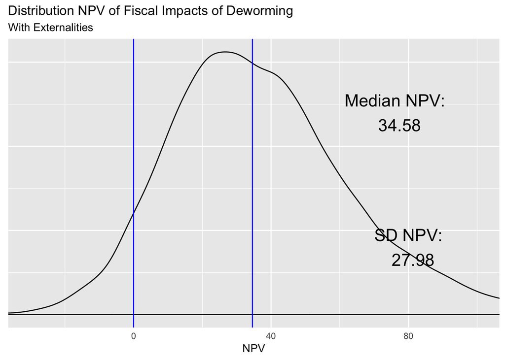

```r
npv_for_text <- paste("Median NPV:\n ", round(median(npv_sim), 2))
npv_for_text2 <- paste("SD NPV:\n ", round(sd(npv_sim), 2))

ggplot() +
  geom_density(aes(x = npv_sim,
                   alpha = 1/2), kernel = "gau") +
  geom_vline(xintercept = c(0, median(npv_sim)), col="blue") +
  coord_cartesian(xlim = c(-30,100)) +
  guides(alpha = "none", colour="none") +
  labs(y = NULL,
       x = "NPV" ,
       title = "Distribution NPV of Fiscal Impacts of Deworming",
       subtitle = "With Externalities")+
  annotate("text", x = 2.2 * median(npv_sim), y = 0.012, label = npv_for_text, size = 6)+
  annotate("text", x = 80, y = 0.004, label = npv_for_text2, size = 6)+
  theme(axis.ticks = element_blank(), axis.text.y = element_blank())
```

## Sensitivity Analysis

First we abbreviate all the remaining components of the model that were still written in english into one parameter:

- teacher salary: $P_1$
- teacher benefits: $P_2$
- # Students: $P_3$
- Cost per person per year ($KSH): $P_4$
- Additional years of treatment: $P_5$

Now we can combine all the sub components of equation 1 into on single, very large, expression obtaining:

$$\begin{equation}
NPV =
\tau \sum_{t=0}^{50}\left( \frac{1}{1 + (i - \pi)}\right)^{t}
\left( \frac{52}{ex} \sum_{l \in \{ag, ww, se\}}w_{l}\frac{ h_{l}}{h_{ag} + h_{ww} + h_{se}}
(1 + g)^{Xp}(1 + \hat{\beta_1} Xp + \hat{\beta_2} Xp^2) \right)I(t\geq 10) \times \\
\left(\frac{\lambda_{1,male} + \lambda_{1,female}}{2} + \frac{p \lambda_{2}}{R} \right) -
\frac{P_1 + P_2}{P_3} \sum_{t=0}^{50} \left( \frac{1}{1 + (i - \pi)}\right)^{t} \Delta \overline{E}_{\gamma t}(S1,S2)
-
\left( \frac{P_4 }{ex}\times P_5 \right) Q(S_{2})
\end{equation}$$

- **Note for me:** When checking same output with app, reset values in DD to match sliders (levels and SDs)

### Policy Report A

```r
npv_sim <- sim.data1(nsims = 1e4,
          gov_bonds_vari = 0.129,                #Data
          gov_bonds_sd = 0.1 * gov_bonds,
          inflation_vari = inflation,
          inflation_sd = 0.1 * inflation,
          wage_ag_vari = wage_ag_val,
          wage_ag_sd = 0.1 * wage_ag_val,
          wage_ww_vari = wage_ww_val,
          wage_ww_sd = 0.1 * wage_ww_val,
          profits_se_vari = profits_se_val,
          profits_se_sd = 0.1 * profits_se_val,
          hours_se_cond_vari = 43,
          hours_se_cond_sd = 0.1 * hours_se_cond_val,
          hours_ag_vari = hours_ag_val,
          hours_ag_sd = 0.1 * 7,
          hours_ww_vari = 6,
          hours_ww_sd = 0.1 * hours_ww_val,
          hours_se_vari = 5,
          hours_se_sd = 0.1 * hours_se_val,
          ex_rate_vari = ex_rate_val,
          ex_rate_sd = 0.1 * 110,
          growth_rate_vari = 0.01,
          growth_rate_sd = 0.1 * growth_rate_val,
          coverage_vari = 0.8,
          coverage_sd = 0.1 * coverage_val,
          saturation_vari = 0.45,
          saturation_sd = 0.1 * saturation_val,
          tax_vari = 0.16,
          tax_sd = 0.1 * tax_val,
          unit_cost_local_vari = unit_cost_local_val,
          unit_cost_local_sd = 0.1 * unit_cost_local_val,
          years_of_treat_vari = years_of_treat_val,
          years_of_treat_sd = 0.1 * years_of_treat_val,
          lambda1_vari = c(lambda1_vals[1], lambda1_vals[2]),
          lambda1_sd = c(0.17, 0.17),
          lambda2_vari = lambda2_val,
          lambda2_sd = 0.5 * lambda2_val,
          q_full_vari = q_full_val,
          q_full_sd = 0.1 * q_full_val,
          q_zero_vari = q_zero_val,
          q_zero_sd = 0.1 * q_zero_val,
          coef_exp_vari = c(0.002, -0.0002),
          coef_exp_sd = c(0.001 , 0.001),
          teach_sal_vari = 7000,
          teach_sal_sd = 0.1 * teach_sal_val,
          teach_ben_vari = teach_ben_val,
          teach_ben_sd = 0.1 * teach_ben_val,
          n_students_vari = 36,
          n_students_sd = 0.1 * n_students_val,
          include_ext_vari = TRUE,
          delta_ed_par1 = 1,
          delta_ed_sd1 = 1,
          delta_ed_par2 = 1,
          delta_ed_sd2 = 1
          )

npv_for_text <- paste("Median NPV:\n ", round(median(npv_sim), 2))

ggplot() +
  geom_density(aes(x = npv_sim,
                   alpha = 1/2), kernel = "gau") +
  geom_vline(xintercept = c(0, median(npv_sim)), col="blue") +
  coord_cartesian(xlim = c(-30,100)) +
  guides(alpha = "none", colour="none") +
  labs(y = NULL,
       x = "NPV" ,
       title = "Distribution NPV of Fiscal Impacts of Deworming",
       subtitle = "With Externalities")+
  annotate("text", x = 2.2 * median(npv_sim), y = 0.012, label = npv_for_text, size = 6)+
  theme(axis.ticks = element_blank(), axis.text.y = element_blank())
```

[output not shown]

## Questions (for Michael, Ted or Grace)

- where are the $N_\lambda$ in the spreadsheet?
- To me: should I add small output after each subsection?
- What are the terms behind the calculation of $R$?
- Clarify circularity behind $R$ and $p$
- Why $\Delta \overline{E}_{\gamma t}(S1,S2)$ is not used for separate groups (men and female)

## Next steps:

- set up each primitive parama as normal(value,sd = something). DONE
- run 1000? 10000? times and obtain figure 1. DONE
- Finish description of last component. DONE
- deploy shiny app with one slider. DONE
  - wrap everything in a horrible function DONE
  - add additional sliders DONE
- Display value for NPV DONE
- reproduce results with and without externalities reactively DONE
- bud gif for slides DONE
- add sliders for SD of each component DONE
- describe MC and SA. DONE
- deploy shiny app and build layered document.
- built two examples: one highly negative and other highly positive.
- Look for insights out of the shiny app.
  - Tax?
  - $\lambda_2 = 0$ but current prices.
  - play with SDs
  - returns to ed
  - $R, p, Q$
  - Unit costs
  - Example to connect with power calc?
- Made flexible to 20 years
- Overall welfare NEXT
- Scale lambda 1 to infection rates.
- Embed restrictions that come from theory (or empirical regularities) like relationship between unemployment and inflation.